# Brain Exam #1 and Some Linear Models

## [CHECK-IN : Practice Brain Exam (no R)](https://docs.google.com/forms/d/e/1FAIpQLSdlow6vZFcpooGbTACiW2HgsEfbVHkSarB2rZwpNvgUF-HyHQ/viewform?usp=header)

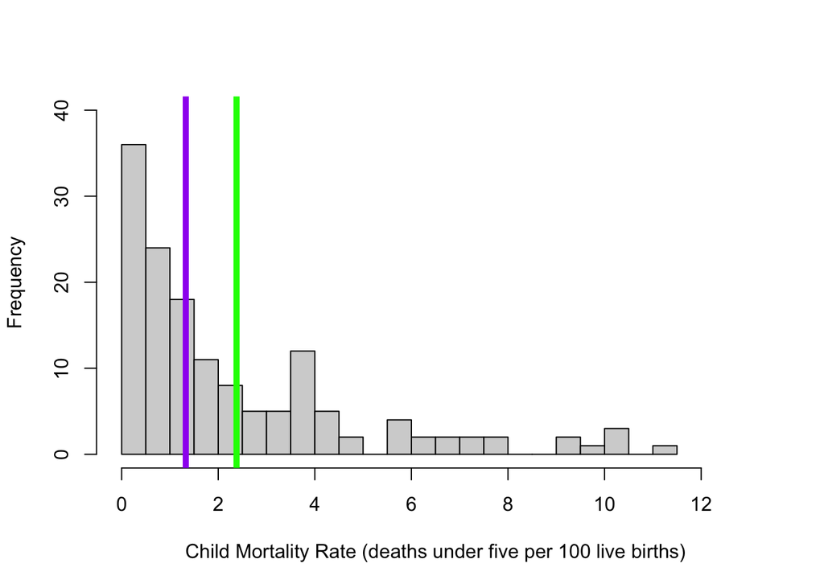

```r
d <- read.csv("~/Dropbox/!WHY STATS/Chapter Datasets/Our World in Happy Data/DATASET_happy_data.csv", stringsAsFactors = T)
hist(d$Child.Mortality, breaks = 20, xlim = c(0,13), ylim = c(0,40), main = "",
     xlab = "Child Mortality Rate (deaths under five per 100 live births)")
abline(v = mean(d$Child.Mortality, na.rm = T), lwd = 5, col = "green")
abline(v = median(d$Child.Mortality, na.rm = T), lwd = 5, col = "purple")
```

## The Brain Exam : More Practice?

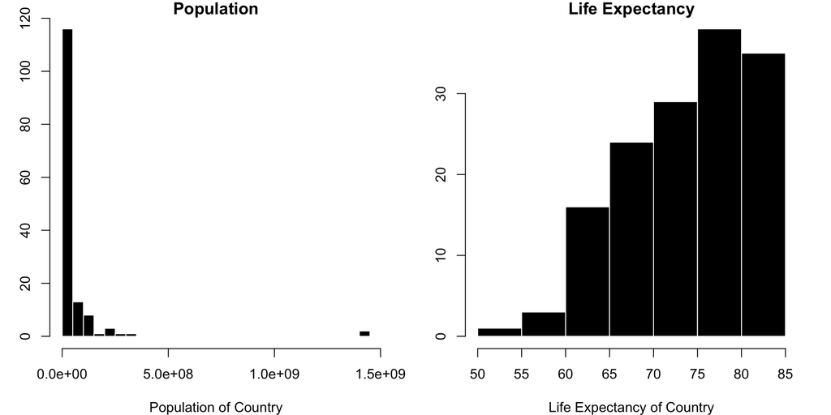

```r
par(mfrow = c(1,2), cex = 1, mar = c(4,3,1,2))
hist(d$Population, col = "black", bor = "White", main = "Population", breaks = 40, xlab = "Population of Country")
hist(d$LifeExpectancy, col = "black", bor = "White", main = "Life Expectancy", xlab = "Life Expectancy of Country")
```

## The Brain Exam.

- I’ll show you a graph and some questions
- Answer the questions.
- NO R / NO INTERNET / AI TOOLS - JUST YOUR OWN BRAIN.
- Can get 50% of any lost points back when I post the key.

## Ready?

## The Linear Model : Prediction is a Line

### RECAP : The Mean as a Model (with Error)

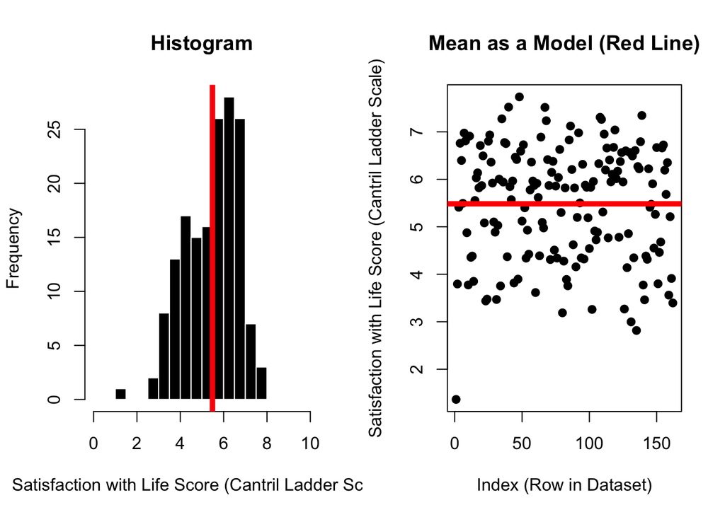

### RECAP : The Mean as Prediction?

$\huge y_i = \hat{Y} + \epsilon_i$

$\Large y_i$ = the DV = the individual’s actual score we are trying to predict.

- `on the graph: each individual dot`

$\Large \hat{Y}$ = our prediction (the mean).

- `on the graph: the solid red line`

$\Large \epsilon$ = residual error = difference between predicted and actual values of y

- `on the graph: the distance between each dot and the line.`

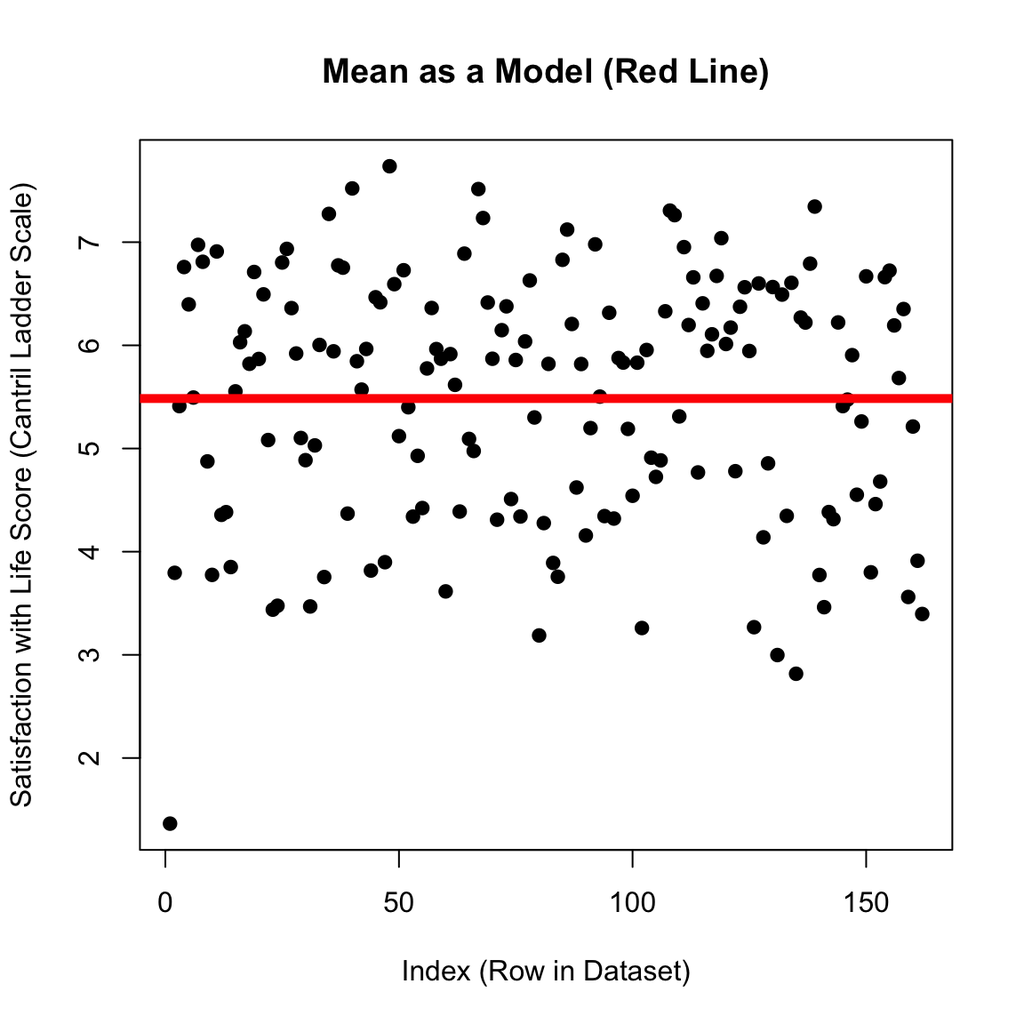

```r
plot(d$SWLS_24,
     main = "Mean as a Model (Red Line)",
     pch = 19,
     xlab = "Index (Row in Dataset)",
     ylab = "Satisfaction with Life Score (Cantril Ladder Scale)")
abline(h = mean(d$SWLS_24, na.rm = T), lwd = 5, col = 'red')
```

### RECAP : The Mean as Prediction With Error

$\huge \epsilon_i = y_i - \hat{Y}$

Error = actual score - prediction (the mean)

```r
residual <- d$SWLS_24 - mean(d$SWLS_24, na.rm = T)
SST <- sum(residual^2, na.rm = T)
SST
```

```
[1] 233.827
```

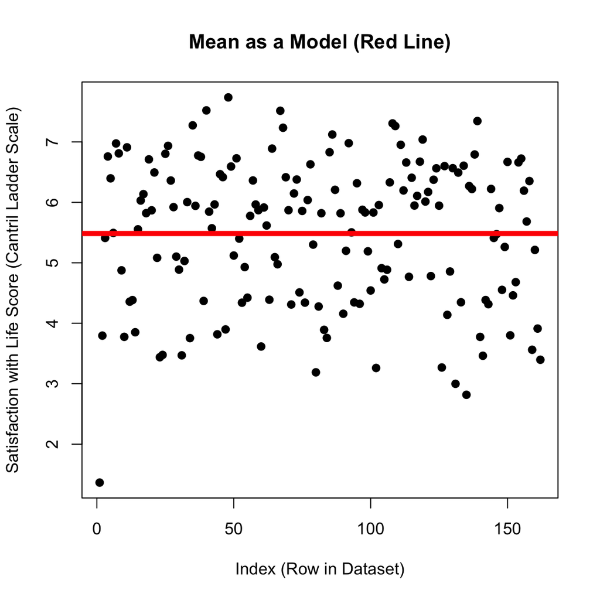

```r
plot(d$SWLS_24,
     main = "Mean as a Model (Red Line)",
     pch = 19,
     xlab = "Index (Row in Dataset)",
     ylab = "Satisfaction with Life Score (Cantril Ladder Scale)")
abline(h = mean(d$SWLS_24, na.rm = T), lwd = 5, col = 'red')
```

### KEY IDEA : The mean is an okay starting place for our predictions, but we can try to do better!

| **the mean** | **the linear model ™ ©** |
| --- | --- |

### RECAP : Predictions with Linear Models

- DV ~ IV1 + error
  - We make a prediction about one variable (the DV)…
  - using information from others (the IVs)…
  - and accept that our prediction will have error.
- Length of a Romantic Relationship ~ ______ + _____ + _______ + ….. + ______ + error

### DISCUSS : Making Predictions

- how would the variables (below) help (or not) predict country happiness in 2024?
- what other variables might be important to include in the data?

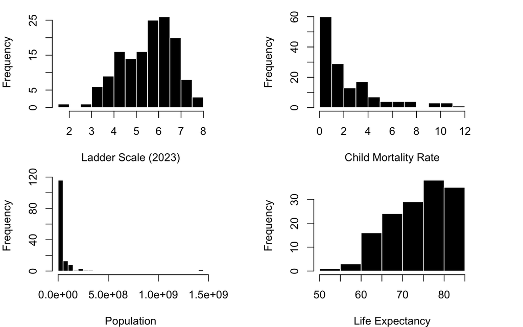

```r
par(mfrow = c(2,2), cex = 1, mar = c(4,4,1,4))
hist(d$SWLS_23, col = "black", bor = "White", xlab = "Ladder Scale (2023)", main = "")
hist(d$Child.Mortality, col = "black", bor = "White", xlab = "Child Mortality Rate", main = "")
hist(d$Population, col = "black", bor = "White", xlab = "Population", breaks = 40, main = "")
hist(d$LifeExpectancy, col = "black", bor = "White", xlab = "Life Expectancy", main = "")
```

### TIME TO PLAY : WHERE’S THE LINE

- Where the Line?
- There the Line!

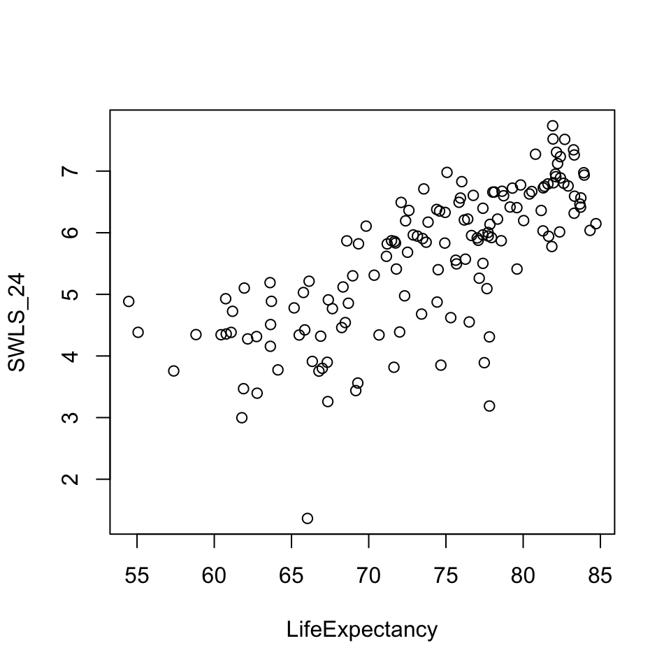

```r
plot(SWLS_24 ~ LifeExpectancy, data = d)
```

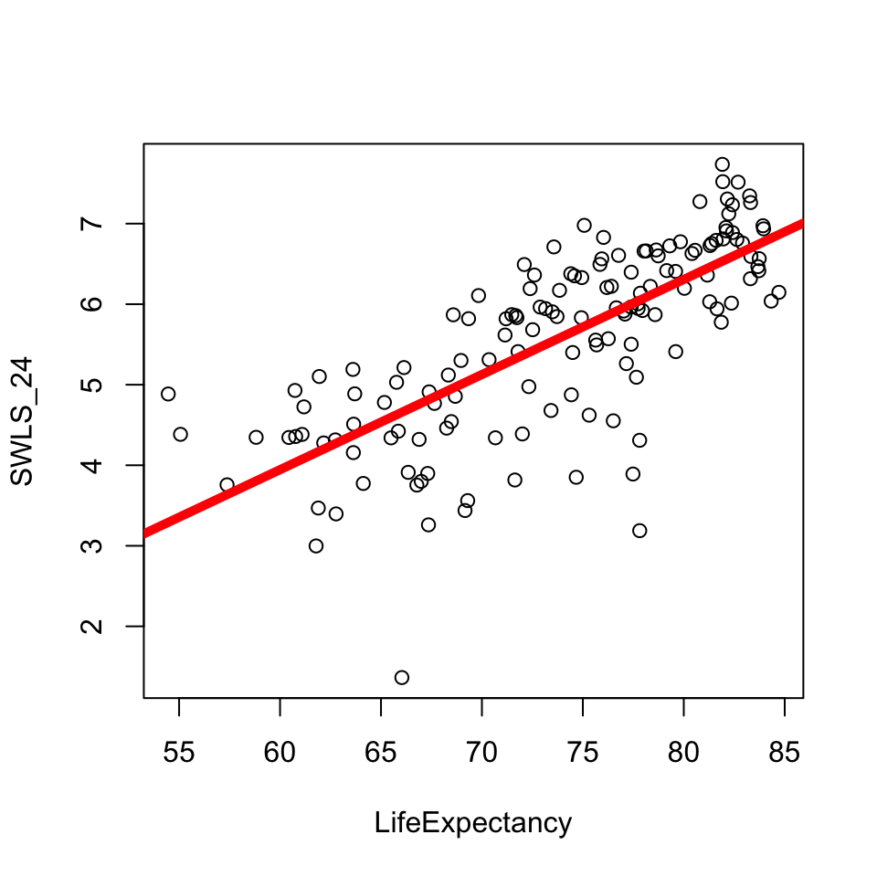

```r
mod <- lm(SWLS_24 ~ LifeExpectancy, data = d) # defines the model; saves as mod
plot(SWLS_24 ~ LifeExpectancy, data = d) # graphs the relationship.
abline(mod, lwd = 5, col = 'red') # draws a red line of width five based on mod
```

### What’s Going On : It’s a Line

$\Huge y_i = a + b_1 * X_i + \epsilon_i$

```r
round(coef(mod), 2)
```

```
   (Intercept) LifeExpectancy
         -3.14           0.12
```

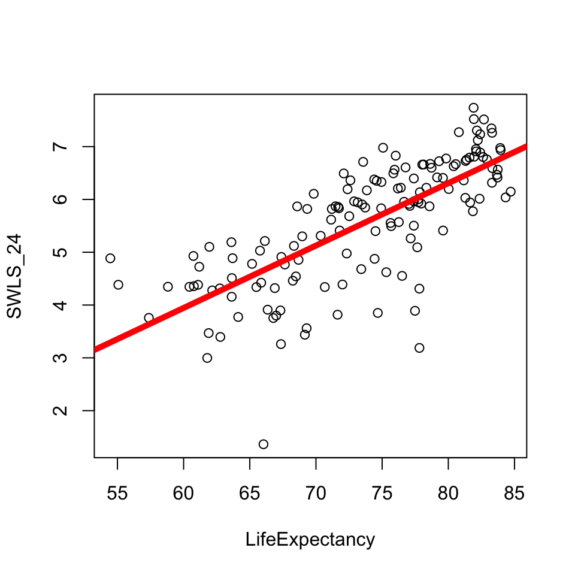

```r
mod <- lm(SWLS_24 ~ LifeExpectancy, data = d)
plot(SWLS_24 ~ LifeExpectancy, data = d)
abline(mod, lwd = 5, col = 'red')
```

$\Large y_i$ = the DV = each actual score on the DV.

- `on the graph:** each dot on the y-axis`

$\Large a$ = the intercept = starting place for our prediction (“the predicted value of y when all x values are zero”.)

- `on the graph:** the value of the line at X = 0`

$\Large X_i$ = the IV = the actual score on the IV.

- `on the graph: the value of each dot on the x-axis`

$\Large b_1$ = the slope = an adjustment to our prediction of y based changes in x

- `on the graph: how much the line increases in y value when x-values increase by 1 unit.`

$\Large \epsilon_i$ = residual error = the distance between actual y and predicted y

- `on the graph: the distance between each individual data point and the line.`

## The Linear Model : Error

Which model has dots that are closer to the line?

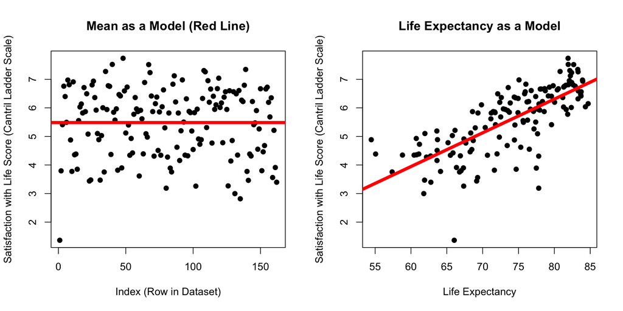

```r
par(mfrow = c(1,2))
plot(d$SWLS_24,
     main = "Mean as a Model (Red Line)",
     pch = 19,
     xlab = "Index (Row in Dataset)",
     ylab = "Satisfaction with Life Score (Cantril Ladder Scale)")
abline(h = mean(d$SWLS_24, na.rm = T), lwd = 5, col = 'red')

plot(SWLS_24 ~ LifeExpectancy, data = d, pch = 19, main = "Life Expectancy as a Model",
     ylab = "Satisfaction with Life Score (Cantril Ladder Scale)",
     xlab = "Life Expectancy")
abline(mod, lwd = 5, col = 'red')
```

## The Linear Model : Counting Error

- How big is the difference in error?
- Giving Context to the Difference in Error

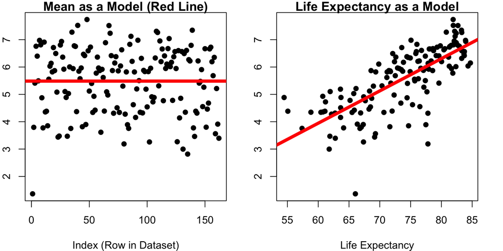

```r
par(mfrow = c(1,2), cex = 1, mar = c(4, 2, 1, 2))
plot(d$SWLS_24,
     main = "Mean as a Model (Red Line)",
     pch = 19,
     xlab = "Index (Row in Dataset)",
     ylab = "Satisfaction with Life Score")
abline(h = mean(d$SWLS_24, na.rm = T), lwd = 5, col = 'red')

plot(SWLS_24 ~ LifeExpectancy, data = d, pch = 19, main = "Life Expectancy as a Model",
     ylab = "Satisfaction with Life Score",
     xlab = "Life Expectancy")
abline(mod, lwd = 5, col = 'red')
```

```r
SWLS24 <- mod$model$SWLS_24 # using data that also have life expectancy
residual <- SWLS24 - mean(SWLS24) # error
SST <- sum(residual^2, na.rm = T) # sum of squared errors
SST # total sum of squared errors
```

```
[1] 195.867
```

```r
SSM <- sum(mod$residuals^2) # R saves the residuals for you
SSM # hooray!
```

```
[1] 89.63457
```

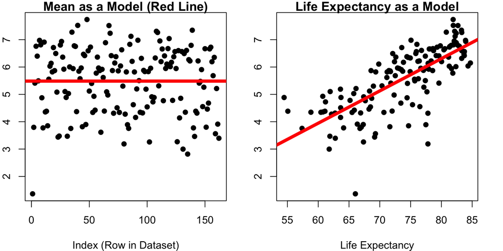

```r
par(mfrow = c(1,2), cex = 1, mar = c(4, 2, 1, 2))
plot(d$SWLS_24,
     main = "Mean as a Model (Red Line)",
     pch = 19,
     xlab = "Index (Row in Dataset)",
     ylab = "Satisfaction with Life Score")
abline(h = mean(d$SWLS_24, na.rm = T), lwd = 5, col = 'red')

plot(SWLS_24 ~ LifeExpectancy, data = d, pch = 19, main = "Life Expectancy as a Model",
     ylab = "Satisfaction with Life Score",
     xlab = "Life Expectancy")
abline(mod, lwd = 5, col = 'red')
```

```r
SST - SSM # the total difference
```

```
[1] 106.2324
```

```r
(SST - SSM)/SST # the relative difference
```

```
[1] 0.5423702
```

```r
summary(mod)$r.squared # this is called R^2
```

```
[1] 0.5423702
```